# Sources of public data:

First step: import the necessary libraries.

Pandas: open source, BSD-licensed library providing high-performance, easy-to-use data structures and data analysis

[How to install Pandas](http://pandas.pydata.org/pandas-docs/stable/install.html)

```python
import pandas as pd
```

Quandl: search engine for numerical data.

[How to install Quandl](https://www.quandl.com/help/python)

```python
import Quandl
```

If you have not done so already, go to Quandl and register to get a free API key:

```python
API_key = '<your API key>'
```

How to get a dataframe via the Quandl API:

```python
# Quandl.get(some_reference, returns = 'pandas', authtoken=API_key)
```

Matplotlib: is a plotting library for the Python

[How to install Matplotlib](http://matplotlib.org/users/installing.html)

```python
import matplotlib.pyplot as plt
# the following is so that you don't get pop ups, but rather the graphs happen in line:
%matplotlib inline
```

## Global data:

Each database comes with it's own documentation, but Quanld does a good job of standardizing it.

### Example 1: United nations data (https://www.quandl.com/data/UNDATA)

Format: {DATABASE}/{SUBJECT}*{INDICATOR}*{COUNTRY} ([source](https://www.quandl.com/data/UNDATA/documentation/documentation))

```python
reference = 'UNDATA/INDCOM_SPOR_PRT'
UN_data = Quandl.get(reference, returns = 'pandas', authtoken=API_key)
```

Pulling data on portuguese sports equipment production:

- UNDATA is the database code
- INDCOM is the subject code for "Industrial Commodity Statistics".
- SPOR is the code for the indicator "Sports Equipment Production".
- PRT is the code for country "Portugal".

Let's try plotting what we just called:

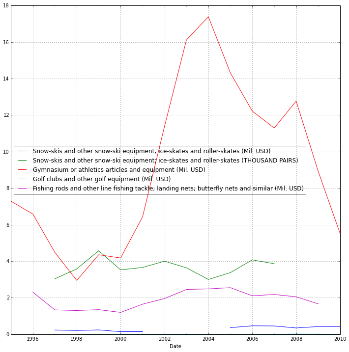

```python
UN_data.plot(figsize = (12,12))
plt.show()
```

## World health organization data ([source](https://www.quandl.com/data/WHO/documentation/documentation)):

Format: WHO/{country code}_{indicator}

- Rwanda: 16700
- Incidence of tuberculosis (per 100 000 population per year): 18

```python
reference = 'WHO/16700_18'

Turbec_Rwanda = Quandl.get(reference, returns = 'pandas', authtoken=API_key)
```

Again, let's plot what we just called:

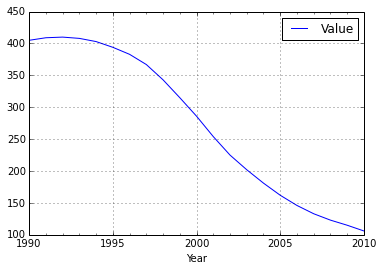

```python
Turbec_Rwanda.plot()
```

## European Central Bank

Greece Bank of Greece Executed trades Debt securities Quantity

```python
reference = 'ECB/SEE_A_GR_BGR0_EXT_M_Q'
greece = Quandl.get(reference, returns = 'pandas', authtoken=API_key)
```

```
[]
```

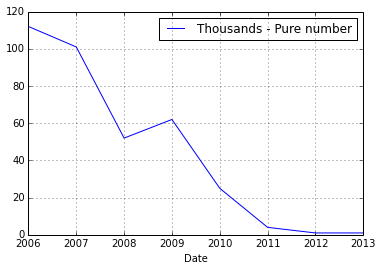

```python
greece.plot()
plt.plot()
```

## Energy statistics (US):

```python
reference = 'DOE/COAL'
coal_prices_by_region = Quandl.get(reference, returns = 'pandas', authtoken=API_key)
```

```
[]
```

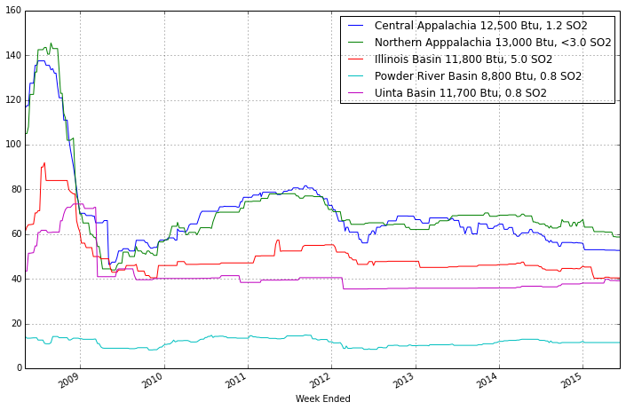

```python
coal_prices_by_region.plot(figsize = (12,8))
plt.plot()
```

[Source](https://www.quandl.com/data/DOE)

## US government data:

```python
reference = 'USDATA/PETROLEUM_IMPORTS_SAUDIARABIA'
US_oil_imports_saudi = Quandl.get(reference, returns = 'pandas', authtoken=API_key)
```

```
[]
```

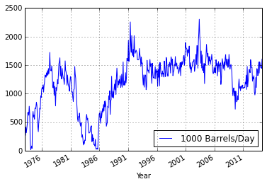

```python
US_oil_imports_saudi.plot()
plt.plot()
```

## Sources of data that don't seem (when I wrote this) to be on Quandl:

- http://dados.gov.pt/ - Portuguese government data
- http://www.base.gov.pt - Online public contracts